# Proyecto INF-578 Máquinas de Aprendizaje

## Predicción de Incendios Forestales utilizando técnicas de Máquinas de Aprendizaje

### Daniel San Martín

## Introducción

Los incendios forestales son unos de los problemas medioambientales de mayor interés por el daño que generan en términos económicos, ambientales y por poner en peligro vidas humanas [1]. Es por esto último que poder modelar estos fenómenos se convierte en una tarea de vital importancia.

Según Preisler y Ager [2] los modelos de incendios se pueden agrupar en tres tipos:

- De riesgo: intentan cuantificar la probabilidad y potenciales efectos ante posibles episodios de incendio.
- De propagación: modelan la propagación del fuego y existen desde enfoques fı́sicos hasta modelos de regresión para estimar la tasa de propagación
- De efecto: son importantes para estudiar la administración y gestión de los combustibles, por ejemplo el control de mortalidad de árboles o análisis de ecosistemas, entre otros.

Este proyecto tiene como objetivo analizar el trabajo desarrollado en el artículo "**A Data Mining Approach to Predict Forest Fires using Meteorological Data**" de Paulo Cortez y Aníbal Morais [3]. Para esto se realiza una comparación, análisis y propuesta de modelos sobre el trabajo desarrollado por los autores mencionados.

## Desarrollo

### Datos y pre-procesamiento

Los datos utilizados en este trabajo fueron extraidos del parque natural de Montesinho, en Trás-os-Montes región del noreste de Portugal, y contienen información sobre las áreas de terreno quemada en episodios de incendios entre enero del 2000 y diciembre del 2003.

```python
# Load data
df = pd.read_csv("./data/forestfires.csv", sep = ",",header = 0)

# Categorize month and days
df.month.replace(('jan','feb','mar','apr','may','jun','jul','aug','sep','oct','nov','dec'),(1,2,3,4,5,6,7,8,9,10,11,12), inplace=True)
df.day.replace(('mon','tue','wed','thu','fri','sat','sun'),(1,2,3,4,5,6,7), inplace=True)

# Data information
print("Shape: ", df.shape)
df.info()
df.describe()
```

```
Shape:  (517, 13)
<class 'pandas.core.frame.DataFrame'>
RangeIndex: 517 entries, 0 to 516
Data columns (total 13 columns):
X        517 non-null int64
Y        517 non-null int64
month    517 non-null int64
day      517 non-null int64
FFMC     517 non-null float64
DMC      517 non-null float64
DC       517 non-null float64
ISI      517 non-null float64
temp     517 non-null float64
RH       517 non-null int64
wind     517 non-null float64
rain     517 non-null float64
area     517 non-null float64
dtypes: float64(8), int64(5)
memory usage: 52.6 KB
```

|  | X | Y | month | day | FFMC | DMC | DC | ISI | temp | RH | wind | rain | area |
| --- | --- | --- | --- | --- | --- | --- | --- | --- | --- | --- | --- | --- | --- |
| count | 517.000000 | 517.000000 | 517.000000 | 517.000000 | 517.000000 | 517.000000 | 517.000000 | 517.000000 | 517.000000 | 517.000000 | 517.000000 | 517.000000 | 517.000000 |
| mean | 4.669246 | 4.299807 | 7.475822 | 4.259188 | 90.644681 | 110.872340 | 547.940039 | 9.021663 | 18.889168 | 44.288201 | 4.017602 | 0.021663 | 12.847292 |
| std | 2.313778 | 1.229900 | 2.275990 | 2.072929 | 5.520111 | 64.046482 | 248.066192 | 4.559477 | 5.806625 | 16.317469 | 1.791653 | 0.295959 | 63.655818 |
| min | 1.000000 | 2.000000 | 1.000000 | 1.000000 | 18.700000 | 1.100000 | 7.900000 | 0.000000 | 2.200000 | 15.000000 | 0.400000 | 0.000000 | 0.000000 |
| 25% | 3.000000 | 4.000000 | 7.000000 | 2.000000 | 90.200000 | 68.600000 | 437.700000 | 6.500000 | 15.500000 | 33.000000 | 2.700000 | 0.000000 | 0.000000 |
| 50% | 4.000000 | 4.000000 | 8.000000 | 5.000000 | 91.600000 | 108.300000 | 664.200000 | 8.400000 | 19.300000 | 42.000000 | 4.000000 | 0.000000 | 0.520000 |
| 75% | 7.000000 | 5.000000 | 9.000000 | 6.000000 | 92.900000 | 142.400000 | 713.900000 | 10.800000 | 22.800000 | 53.000000 | 4.900000 | 0.000000 | 6.570000 |
| max | 9.000000 | 9.000000 | 12.000000 | 7.000000 | 96.200000 | 291.300000 | 860.600000 | 56.100000 | 33.300000 | 100.000000 | 9.400000 | 6.400000 | 1090.840000 |

Notamos que el conjunto de datos posee un total de **517** registros con **12** atributos más la variable dependiente, en este caso el área quemada. Los datos contenidos corresponden a:

1. Datos espaciales: mapeo del terreno a coordenadas $x$ e $y$.
2. Datos temporales: día y mes del año.
3. Datos del sistema FWI: códigos asociados al material y cantidad de combustible, además de un índice para evaluar la velocidad del fuego.
4. Datos meteorológicos: temperatura (°C), humedad relativa (%), velocidad del viento (km/hr) y precipitaciones en (mm/m²).

El área, la variable dependiente, se encuentra expresada en hectáreas (ha).

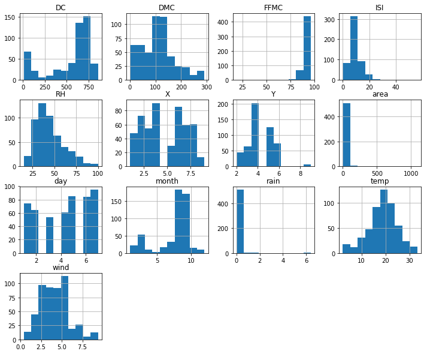

```python
df.hist(figsize=(12, 10))
plt.show()
```

De los histogramas podemos notar que la variable dependiente tiene muchos valores cercanos a $0$, en comparación a los otros, lo que podría dificultar la predicción de estos. Además, de la tabla anterior, podemos ver la diferencia de escala de estos valores que también podría influir considerablemente en el problema.

```python
df.corr()
```

|  | X | Y | month | day | FFMC | DMC | DC | ISI | temp | RH | wind | rain | area |
| --- | --- | --- | --- | --- | --- | --- | --- | --- | --- | --- | --- | --- | --- |
| X | 1.000000 | 0.539548 | -0.065003 | -0.024922 | -0.021039 | -0.048384 | -0.085916 | 0.006210 | -0.051258 | 0.085223 | 0.018798 | 0.065387 | 0.063385 |
| Y | 0.539548 | 1.000000 | -0.066292 | -0.005453 | -0.046308 | 0.007782 | -0.101178 | -0.024488 | -0.024103 | 0.062221 | -0.020341 | 0.033234 | 0.044873 |
| month | -0.065003 | -0.066292 | 1.000000 | -0.050837 | 0.291477 | 0.466645 | 0.868698 | 0.186597 | 0.368842 | -0.095280 | -0.086368 | 0.013438 | 0.056496 |
| day | -0.024922 | -0.005453 | -0.050837 | 1.000000 | -0.041068 | 0.062870 | 0.000105 | 0.032909 | 0.052190 | 0.092151 | 0.032478 | -0.048340 | 0.023226 |
| FFMC | -0.021039 | -0.046308 | 0.291477 | -0.041068 | 1.000000 | 0.382619 | 0.330512 | 0.531805 | 0.431532 | -0.300995 | -0.028485 | 0.056702 | 0.040122 |
| DMC | -0.048384 | 0.007782 | 0.466645 | 0.062870 | 0.382619 | 1.000000 | 0.682192 | 0.305128 | 0.469594 | 0.073795 | -0.105342 | 0.074790 | 0.072994 |
| DC | -0.085916 | -0.101178 | 0.868698 | 0.000105 | 0.330512 | 0.682192 | 1.000000 | 0.229154 | 0.496208 | -0.039192 | -0.203466 | 0.035861 | 0.049383 |
| ISI | 0.006210 | -0.024488 | 0.186597 | 0.032909 | 0.531805 | 0.305128 | 0.229154 | 1.000000 | 0.394287 | -0.132517 | 0.106826 | 0.067668 | 0.008258 |
| temp | -0.051258 | -0.024103 | 0.368842 | 0.052190 | 0.431532 | 0.469594 | 0.496208 | 0.394287 | 1.000000 | -0.527390 | -0.227116 | 0.069491 | 0.097844 |
| RH | 0.085223 | 0.062221 | -0.095280 | 0.092151 | -0.300995 | 0.073795 | -0.039192 | -0.132517 | -0.527390 | 1.000000 | 0.069410 | 0.099751 | -0.075519 |
| wind | 0.018798 | -0.020341 | -0.086368 | 0.032478 | -0.028485 | -0.105342 | -0.203466 | 0.106826 | -0.227116 | 0.069410 | 1.000000 | 0.061119 | 0.012317 |
| rain | 0.065387 | 0.033234 | 0.013438 | -0.048340 | 0.056702 | 0.074790 | 0.035861 | 0.067668 | 0.069491 | 0.099751 | 0.061119 | 1.000000 | -0.007366 |
| area | 0.063385 | 0.044873 | 0.056496 | 0.023226 | 0.040122 | 0.072994 | 0.049383 | 0.008258 | 0.097844 | -0.075519 | 0.012317 | -0.007366 | 1.000000 |

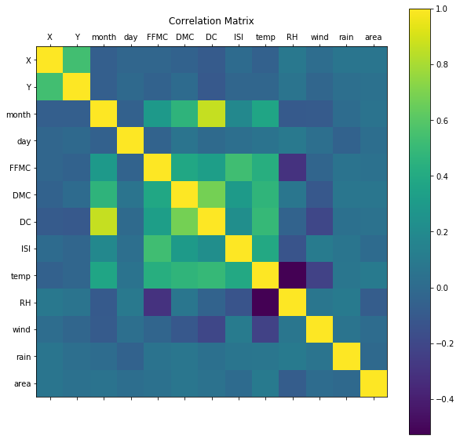

```python
plot_corr(df)
```

Al analizar la correlación entre los datos podemos ver que existe una mayor relación entre los datos del sistema FWI y la temperatura. Esto tiene sentido dado que para calcularlos se utilza la temperatura como uno de los elementos de cálculo. Además, entre ellos también existe una relación considerable.

### División de datos

Se utilizó un 80 % de los datos como entrenamiento y el restante como datos de prueba. El conjunto de entrenamiento es exclusivo para la selección de los modelos y el de prueba para evaluar el rendimiento de los modelos.

### Transformación del target

Del análisis realizado anteriormente notamos que existe mayor cantidad de incendios "pequeños", es por esto que se sugiere aplicar la transformación logarítmica $y=ln(x+1)$ para incluir un poco de simetría y además escalar los datos.

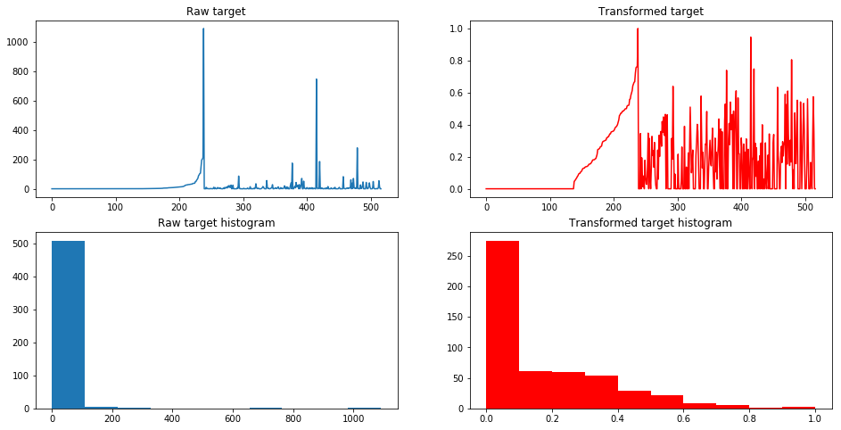

```python
# Comparison plot
plt.figure(figsize=(16, 8))
plt.subplot(2, 2, 1)
plt.plot(y.values)
plt.title("Raw target")
plt.subplot(2, 2, 2)
plt.plot(y_sc, 'r')
plt.title("Transformed target")
plt.subplot(2, 2, 3)
plt.hist(y.values)
plt.title("Raw target histogram")
plt.subplot(2, 2, 4)
plt.hist(y_sc, color='red')
plt.title("Transformed target histogram")
plt.show()
```

### Evaluación de modelos

Para evaluar la calidad de los modelos se utilizaran las méticas: $MAE$, $MSE$ y $RMSE$ para comparar los resultados del artículo guía.

### Selección de parámetros

Para la selección de los hiperparámetros de los modelos, se realizó un *Grid Search* con *Cross Validation* ($K=10$). La métrica de selección fue el $MSE$.

## Linear Regression

```python
lr = LR()
```

```python
lr.fit(X_train_sc, y_sc)
```

```
LinearRegression(copy_X=True, fit_intercept=True, n_jobs=1, normalize=False)
```

```python
lr_y_pred = lr.predict(X_test_sc)
printScores(y_test, inverseTransformTarget(lr_y_pred.reshape(-1, 1), y_scaler))
```

```
MSE: 12069.9164
RMSE: 109.8632
MAE: 19.5794
```

## Decision Trees

```python
dtr_parameters = {
    'criterion': ['mse', 'mae'],
    'splitter': ['best', 'random'],
    'max_depth': [10, 50, 100]
}
```

```python
dtr_models, dtr_d, dtr_t, dtr_m = GSCVData(DTR(), datasets, targets, dtr_parameters, scorers, cv_)
```

```
Best model configuration:
Parameters: {'criterion': 'mae', 'max_depth': 10, 'splitter': 'random'}
Best Score: -0.0709
```

```python
CVScores(dtr_models[dtr_m])
```

|  | Metric | Score |
| --- | --- | --- |
| 0 | Train MSE: | 0.028212 |
| 1 | Train MAE: | 0.087836 |
| 2 | Validation MSE: | 0.070906 |
| 3 | Validation MAE: | 0.204900 |

```python
dt = dtr_models[dtr_m].best_estimator_
dt_y_pred = dt.predict(X_test_sc)
printScores(y_test, inverseTransformTarget(dt_y_pred.reshape(-1, 1), y_scaler))
```

```
MSE: 11575.8427
RMSE: 107.5911
MAE: 15.0174
```

## SVM

```python
svr_parameters = [
    {'C': [1, 10, 100], 'epsilon': [0.001, 0.01, 0.1], 'kernel': ['linear']},
    {'C': [1, 10, 100], 'epsilon': [0.001, 0.01, 0.1],
         'kernel': ['poly'], 'degree': [3, 4, 5], 'gamma': [0.001, 0.0001]},
    {'C': [1, 10, 100], 'epsilon': [0.001, 0.01, 0.1], 'kernel': ['rbf'], 'gamma': [0.001, 0.0001]},
    {'C': [1, 10, 100], 'epsilon': [0.001, 0.01, 0.1], 'kernel': ['sigmoid'], 'gamma': [0.001, 0.0001]}
 ]
```

```python
svr_models, svr_d, svr_t, svr_m = GSCVData(SVR(), datasets, targets, svr_parameters, scorers, cv_)
```

```
Best model configuration:
Parameters: {'C': 1, 'degree': 5, 'epsilon': 0.1, 'gamma': 0.0001, 'kernel': 'poly'}
Best Score: -0.0461
```

```python
CVScores(svr_models[svr_m])
```

|  | Metric | Score |
| --- | --- | --- |
| 0 | Train MSE: | 0.041764 |
| 1 | Train MAE: | 0.157116 |
| 2 | Validation MSE: | 0.046120 |
| 3 | Validation MAE: | 0.169270 |

```python
svr = svr_models[svr_m].best_estimator_
svr_y_pred = svr.predict(X_test_sc)
printScores(y_test, inverseTransformTarget(svr_y_pred.reshape(-1, 1), y_scaler))
```

```
MSE: 12135.2504
RMSE: 110.1601
MAE: 19.6729
```

## Neural Network

```python
nnr_parameters = {
    'hidden_layer_sizes': [(5, ), (10, ), (20, )],
    'activation':  ['identity', 'logistic', 'relu'] ,
    'solver': ['lbfgs', 'sgd', 'adam'],
    'alpha': [0.001, 0.01, 0.1],
    'batch_size': [50, 100, 200],
}
```

```python
nnr_models, nnr_d, nnr_t, nnr_m = GSCVData(MLPR(random_state=seed), datasets, targets, nnr_parameters, scorers, cv_)
```

```
Best model configuration:
Parameters: {'activation': 'logistic', 'alpha': 0.1, 'batch_size': 50, 'hidden_layer_sizes': (20,), 'solver': 'adam'}
Best Score: -0.0457
```

```python
CVScores(nnr_models[nnr_m])
```

|  | Metric | Score |
| --- | --- | --- |
| 0 | Train MSE: | 0.037896 |
| 1 | Train MAE: | 0.158520 |
| 2 | Validation MSE: | 0.045662 |
| 3 | Validation MAE: | 0.177106 |

```python
nnr = nnr_models[nnr_m].best_estimator_
nnr_y_pred = nnr.predict(X_test_sc)
printScores(y_test, inverseTransformTarget(nnr_y_pred.reshape(-1, 1), y_scaler))
```

```
MSE: 12079.3711
RMSE: 109.9062
MAE: 19.6552
```

## Bagging

```python
bgr_parameters = {
    'n_estimators': [50, 100, 200],
}
```

```python
bgr_models, bgr_d, bgr_t, bgr_m = GSCVData(BR(random_state=seed, n_jobs=-1), datasets, targets,
                                           bgr_parameters, scorers, cv_)
```

```
Best model configuration:
Parameters: {'n_estimators': 50}
Best Score: -0.0603
```

```python
CVScores(bgr_models[bgr_m])
```

|  | Metric | Score |
| --- | --- | --- |
| 0 | Train MSE: | 0.006518 |
| 1 | Train MAE: | 0.063305 |
| 2 | Validation MSE: | 0.060268 |
| 3 | Validation MAE: | 0.203382 |

```python
bgr = bgr_models[bgr_m].best_estimator_
bgr_y_pred = bgr.predict(X_test_sc)
printScores(y_test, inverseTransformTarget(bgr_y_pred.reshape(-1, 1), y_scaler))
```

```
MSE: 8978.2424
RMSE: 94.7536
MAE: 14.3763
```

## Random Forest

```python
rfr_parameters = {
    'n_estimators': [10, 20, 30],
    'criterion': ['mse', 'mae'],
    'max_depth': [50, 100]
}
```

```python
rfr_models, rfr_d, rfr_t, rfr_m = GSCVData(RFR(random_state=seed, n_jobs=-1),
                                           datasets, targets, rfr_parameters, scorers, cv_)
```

```
Best model configuration:
Parameters: {'criterion': 'mae', 'max_depth': 50, 'n_estimators': 30}
Best Score: -0.0584
```

```python
CVScores(rfr_models[rfr_m])
```

|  | Metric | Score |
| --- | --- | --- |
| 0 | Train MSE: | 0.008026 |
| 1 | Train MAE: | 0.068680 |
| 2 | Validation MSE: | 0.058435 |
| 3 | Validation MAE: | 0.199943 |

```python
rfr = rfr_models[rfr_m].best_estimator_
rfr_y_pred = rfr.predict(X_test_sc)
printScores(y_test, inverseTransformTarget(rfr_y_pred.reshape(-1, 1), y_scaler))
```

```
MSE: 10293.9710
RMSE: 101.4592
MAE: 15.2504
```

## Extremely Randomized Trees

```python
etr_parameters = {
    'n_estimators': [50, 100, 200],
    'criterion': ["mse", "mae"],
    'max_features': ["auto", "sqrt", "log2", None],
    'max_depth': [10, 50, 100]
}
```

```python
etr_models, etr_d, etr_t, etr_m = GSCVData(ETR(random_state=seed, n_jobs=-1), datasets, targets,
                                           etr_parameters, scorers, cv_)
```

```
Best model configuration:
Parameters: {'criterion': 'mse', 'max_depth': 10, 'max_features': 'sqrt', 'n_estimators': 50}
Best Score: -0.0523
```

```python
CVScores(etr_models[etr_m])
```

|  | Metric | Score |
| --- | --- | --- |
| 0 | Train MSE: | 0.015795 |
| 1 | Train MAE: | 0.098231 |
| 2 | Validation MSE: | 0.052315 |
| 3 | Validation MAE: | 0.188978 |

```python
etr = etr_models[etr_m].best_estimator_
etr_y_pred = etr.predict(X_test_sc)
printScores(y_test, inverseTransformTarget(etr_y_pred.reshape(-1, 1), y_scaler))
```

```
MSE: 11764.2572
RMSE: 108.4632
MAE: 18.0386
```

## Adaboost

```python
abr_parameters = {
    'n_estimators': [50, 100, 200],
    'learning_rate': [0.1, 0.5, 1],
    'loss': ['linear', 'square', 'exponential'],
}
```

```python
abr_models, abr_d, abr_t, abr_m = GSCVData(ABR(random_state=seed), datasets, targets, abr_parameters, scorers, cv_)
```

```
Best model configuration:
Parameters: {'learning_rate': 0.1, 'loss': 'exponential', 'n_estimators': 50}
Best Score: -0.0496
```

```python
CVScores(abr_models[abr_m])
```

|  | Metric | Score |
| --- | --- | --- |
| 0 | Train MSE: | 0.032967 |
| 1 | Train MAE: | 0.154462 |
| 2 | Validation MSE: | 0.049644 |
| 3 | Validation MAE: | 0.186854 |

```python
abr = abr_models[abr_m].best_estimator_
abr_y_pred = abr.predict(X_test_sc)
printScores(y_test, inverseTransformTarget(abr_y_pred.reshape(-1, 1), y_scaler))
```

```
MSE: 11957.4573
RMSE: 109.3502
MAE: 19.6501
```

## Gradient Tree Boosting

```python
gbr_parameters = {
    'n_estimators': [50, 100, 200],
    'learning_rate' : [0.1, 0.5, 1],
    'loss': ['ls', 'lad', 'huber'],
    'max_depth': [10, 20, 30],
    'criterion': ['friedman_mse', 'mse', 'mae']
}
```

```python
gbr_models, gbr_d, gbr_t, gbr_m = GSCVData(GBR(random_state=seed), datasets, targets, gbr_parameters, scorers, cv_)
```

```
Best model configuration:
Parameters: {'criterion': 'mse', 'learning_rate': 0.1, 'loss': 'lad', 'max_depth': 30, 'n_estimators': 50}
Best Score: -0.0608
```

```python
CVScores(gbr_models[gbr_m])
```

|  | Metric | Score |
| --- | --- | --- |
| 0 | Train MSE: | 0.001333 |
| 1 | Train MAE: | 0.010600 |
| 2 | Validation MSE: | 0.060808 |
| 3 | Validation MAE: | 0.199098 |

```python
gbr = gbr_models[gbr_m].best_estimator_
gbr_y_pred = gbr.predict(X_test_sc)
printScores(y_test, inverseTransformTarget(gbr_y_pred.reshape(-1, 1), y_scaler))
```

```
MSE: 4255.8656
RMSE: 65.2370
MAE: 8.1275
```

## Resumen Resultados

| Modelo | RMSE | MAE |
| --- | --- | --- |
| LR | 109.86 | 19.58 |
| DT | 107.59 | 15.01 |
| SVM | 110.16 | 19.67 |
| RNA | 109.91 | 19.66 |
| BAG | 94.75 | 14.38 |
| RF | 101.46 | 15.25 |
| ET | 108.46 | 18.04 |
| ADB | 109.35 | 19.65 |
| **GTB** | **65.23** | **8.13** |

## Selección de Características

Los *bagged trees* pueden ser utilizados para evaluar la importancia de los atributos, según las veces que se utilizan en los sub-modelos construidos por el algoritmo. Según los autores de los ET, los resultados de los ET son comparables con otros modelos ensamblados, pero en términos de rendimiento es mucho mejor. Es por esto que se utilizó el ET para aplicar un *feature selection*.

```
Feature ranking:
1. feature 8 (0.122060)
2. feature 0 (0.114277)
3. feature 1 (0.109341)
4. feature 10 (0.104232)
5. feature 9 (0.101058)
6. feature 5 (0.086845)
7. feature 3 (0.084642)
8. feature 6 (0.079293)
9. feature 7 (0.070145)
10. feature 4 (0.068900)
11. feature 2 (0.055340)
12. feature 11 (0.003866)
```

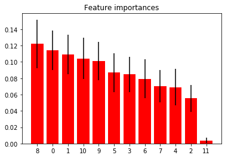

```python
# Build a forest and compute the feature importances
forest = ETR(n_estimators=250, random_state=0)

forest.fit(datasets[0], targets[0])
importances = forest.feature_importances_
std = np.std([tree.feature_importances_ for tree in forest.estimators_], axis=0)
indices = np.argsort(importances)[::-1]

# Print the feature ranking
print("Feature ranking:")

for f in range(X.shape[1]):
    print("%d. feature %d (%f)" % (f + 1, indices[f], importances[indices[f]]))

# Plot the feature importances of the forest
plt.figure()
plt.title("Feature importances")
plt.bar(range(X.shape[1]), importances[indices],
       color="r", yerr=std[indices], align="center")
plt.xticks(range(X.shape[1]), indices)
plt.xlim([-1, X.shape[1]])
plt.show()
```

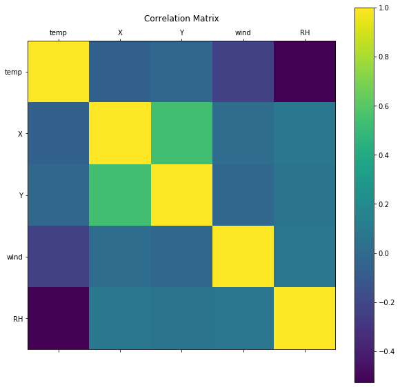

```python
plot_corr(new_X)
```

## Linear Regression

```python
new_lr = LR()
new_lr.fit(new_X, y_sc)
new_lr_y_pred = new_lr.predict(new_X_test)
printScores(y_test, inverseTransformTarget(new_lr_y_pred.reshape(-1, 1), y_scaler))
```

```
MSE: 12082.9417
RMSE: 109.9224
MAE: 19.7426
```

## DT

```python
new_dtr_models, new_dtr_d, new_dtr_t, new_dtr_m = GSCVData(DTR(), [new_X], targets, dtr_parameters, scorers, cv_)
```

```
Best model configuration:
Parameters: {'criterion': 'mse', 'max_depth': 10, 'splitter': 'best'}
Best Score: -0.0763
```

```python
CVScores(new_dtr_models[new_dtr_m])
```

|  | Metric | Score |
| --- | --- | --- |
| 0 | Train MSE: | 0.018631 |
| 1 | Train MAE: | 0.088427 |
| 2 | Validation MSE: | 0.076285 |
| 3 | Validation MAE: | 0.204343 |

```python
new_dt = new_dtr_models[new_dtr_m].best_estimator_
new_dt_y_pred = new_dt.predict(new_X_test)
printScores(y_test, inverseTransformTarget(new_dt_y_pred.reshape(-1, 1), y_scaler))
```

```
MSE: 533.2538
RMSE: 23.0923
MAE: 6.1357
```

## SVM

```python
new_svr_models, new_svr_d, new_svr_t, new_svr_m = GSCVData(SVR(), [new_X], targets, svr_parameters, scorers, cv_)
```

```
Best model configuration:
Parameters: {'C': 1, 'degree': 5, 'epsilon': 0.1, 'gamma': 0.0001, 'kernel': 'poly'}
Best Score: -0.0433
```

```python
CVScores(new_svr_models[new_svr_m])
```

|  | Metric | Score |
| --- | --- | --- |
| 0 | Train MSE: | 0.043309 |
| 1 | Train MAE: | 0.158256 |
| 2 | Validation MSE: | 0.043316 |
| 3 | Validation MAE: | 0.158293 |

```python
new_svr = new_svr_models[new_svr_m].best_estimator_
new_svr_y_pred = new_svr.predict(new_X_test)
printScores(y_test, inverseTransformTarget(new_svr_y_pred.reshape(-1, 1), y_scaler))
```

```
MSE: 12135.2504
RMSE: 110.1601
MAE: 19.6729
```

## MLP

```python
new_nnr_models, new_nnr_d, new_nnr_t, new_nnr_m = GSCVData(MLPR(random_state=seed), [new_X],
                                                           targets, nnr_parameters, scorers, cv_)
```

```
Best model configuration:
Parameters: {'activation': 'logistic', 'alpha': 0.1, 'batch_size': 200, 'hidden_layer_sizes': (20,), 'solver': 'adam'}
Best Score: -0.0440
```

```python
CVScores(new_nnr_models[new_nnr_m])
```

|  | Metric | Score |
| --- | --- | --- |
| 0 | Train MSE: | 0.039741 |
| 1 | Train MAE: | 0.164733 |
| 2 | Validation MSE: | 0.044023 |
| 3 | Validation MAE: | 0.173963 |

```python
new_nnr = new_nnr_models[new_nnr_m].best_estimator_
new_nnr_y_pred = new_nnr.predict(new_X_test)
printScores(y_test, inverseTransformTarget(new_nnr_y_pred.reshape(-1, 1), y_scaler))
```

```
MSE: 12089.5034
RMSE: 109.9523
MAE: 19.8279
```

## Bagging

```python
new_bgr_models, new_bgr_d, new_bgr_t, new_bgr_m = GSCVData(BR(random_state=seed, n_jobs=-1), [new_X], targets,
                                           bgr_parameters, scorers, cv_)
```

```
Best model configuration:
Parameters: {'n_estimators': 100}
Best Score: -0.0521
```

```python
CVScores(new_bgr_models[new_bgr_m])
```

|  | Metric | Score |
| --- | --- | --- |
| 0 | Train MSE: | 0.006361 |
| 1 | Train MAE: | 0.063271 |
| 2 | Validation MSE: | 0.052071 |
| 3 | Validation MAE: | 0.187656 |

```python
new_bgr = new_bgr_models[new_bgr_m].best_estimator_
new_bgr_y_pred = new_bgr.predict(new_X_test)
printScores(y_test, inverseTransformTarget(new_bgr_y_pred.reshape(-1, 1), y_scaler))
```

```
MSE: 9550.7750
RMSE: 97.7281
MAE: 15.0359
```

### RF with FE

```python
new_rfr_models, new_rfr_d, new_rfr_t, new_rfr_m = GSCVData(RFR(random_state=seed, n_jobs=-1),
                                           [new_X], targets, rfr_parameters, scorers, cv_)
```

```
Best model configuration:
Parameters: {'criterion': 'mae', 'max_depth': 100, 'n_estimators': 20}
Best Score: -0.0516
```

```python
CVScores(new_rfr_models[new_rfr_m])
```

|  | Metric | Score |
| --- | --- | --- |
| 0 | Train MSE: | 0.009267 |
| 1 | Train MAE: | 0.070772 |
| 2 | Validation MSE: | 0.051589 |
| 3 | Validation MAE: | 0.186793 |

```python
new_rfr = new_rfr_models[new_rfr_m].best_estimator_
new_rfr_y_pred = new_rfr.predict(new_X_test)
printScores(y_test, inverseTransformTarget(new_rfr_y_pred.reshape(-1, 1), y_scaler))
```

```
MSE: 11255.4788
RMSE: 106.0918
MAE: 15.9184
```

### ETR

```python
new_etr_models, new_etr_d, new_etr_t, new_etr_m = GSCVData(ETR(random_state=seed, n_jobs=-1),
                                                           [new_X], targets, etr_parameters, scorers, cv_)
```

```
Best model configuration:
Parameters: {'criterion': 'mse', 'max_depth': 10, 'max_features': 'sqrt', 'n_estimators': 200}
Best Score: -0.0487
```

```python
CVScores(new_etr_models[new_etr_m])
```

|  | Metric | Score |
| --- | --- | --- |
| 0 | Train MSE: | 0.015498 |
| 1 | Train MAE: | 0.096653 |
| 2 | Validation MSE: | 0.048668 |
| 3 | Validation MAE: | 0.182534 |

```python
new_etr = new_etr_models[new_etr_m].best_estimator_
new_etr_y_pred = new_etr.predict(new_X_test)
printScores(y_test, inverseTransformTarget(new_etr_y_pred.reshape(-1, 1), y_scaler))
```

```
MSE: 11788.0597
RMSE: 108.5728
MAE: 17.5705
```

## Adaboost

```python
new_abr_models, new_abr_d, new_abr_t, new_abr_m = GSCVData(ABR(random_state=seed), [new_X], targets,
                                                           abr_parameters, scorers, cv_)
```

```
Best model configuration:
Parameters: {'learning_rate': 0.1, 'loss': 'exponential', 'n_estimators': 50}
Best Score: -0.0467
```

```python
CVScores(new_abr_models[new_abr_m])
```

|  | Metric | Score |
| --- | --- | --- |
| 0 | Train MSE: | 0.035995 |
| 1 | Train MAE: | 0.162119 |
| 2 | Validation MSE: | 0.046654 |
| 3 | Validation MAE: | 0.183281 |

```python
new_abr = new_abr_models[new_abr_m].best_estimator_
new_abr_y_pred = new_abr.predict(new_X_test)
printScores(y_test, inverseTransformTarget(new_abr_y_pred.reshape(-1, 1), y_scaler))
```

```
MSE: 12020.2183
RMSE: 109.6368
MAE: 19.7053
```

### GBR

```python
new_gbr_models, new_gbr_d, new_gbr_t, new_gbr_m = GSCVData(GBR(random_state=seed), [new_X], targets,
                                                           gbr_parameters, scorers, cv_)
```

```
Best model configuration:
Parameters: {'criterion': 'mae', 'learning_rate': 0.1, 'loss': 'lad', 'max_depth': 20, 'n_estimators': 50}
Best Score: -0.0544
```

```python
CVScores(new_gbr_models[new_gbr_m])
```

|  | Metric | Score |
| --- | --- | --- |
| 0 | Train MSE: | 0.004221 |
| 1 | Train MAE: | 0.024298 |
| 2 | Validation MSE: | 0.054360 |
| 3 | Validation MAE: | 0.182910 |

```python
new_gbr = new_gbr_models[new_gbr_m].best_estimator_
new_gbr_y_pred = new_gbr.predict(new_X_test)
printScores(y_test, inverseTransformTarget(new_gbr_y_pred.reshape(-1, 1), y_scaler))
```

```
MSE: 3743.4002
RMSE: 61.1833
MAE: 9.0934
```

## Resumen Resultados con Selección de Características

| Modelo | RMSE | MAE |
| --- | --- | --- |
| LR | 109.92 | 19.74 |
| **DT** | **23.09** | **6.14** |
| SVM | 110.16 | 19.67 |
| MLP | 109.95 | 19.83 |
| BAG | 97.73 | 15.04 |
| RF | 106.09 | 15.92 |
| ET | 108.57 | 17.57 |
| ADB | 109.64 | 19.7 |
| GTB | 61.18 | 9.09 |

## Conclusiones

Dado que se estaba trabajando con las 12 características del *dataset*, se realizó una estrategia de selección de características basada en el uso de un árbol de decisión (*Extra Tree Regressor* en este caso), y que disminuyó el número de columnas a 5. Gracias a este proceso el Arbol de Decisión obtuvo mejores resultados en comparación a la publicación guía.

Como resumen se muestran los mejores resultados:

[output not shown]

## Referencias

- [1] CONAF (2013). Incendios forestales en chile. http://www.conaf.cl/incendios-forestales/incendios-forestales-en-chile/. Online; accessed 21 Marzo 2018.
- [2] Preisler, H. K., y Ager, A. A. (2013). Forest-fire models. Encyclopedia of Environmetrics.
- [3] Cortez, P., y Morais, A. (2007). A data mining approach to predict forest fires using meteorological data. En J. Neves, M. F. Santos, y J. Machado (Eds.), New trends in artificial intelligence, proceedings of the 13th epia 2007 - portuguese conference on artificial intelligence (p. 512-523). Guimaraes, Portugal. (Available at: http://www.dsi.uminho.pt/~pcortez/fires.pdf)